# Reproducible Research Class Project Week 2

Maria Telpoukhovskaia

November 18, 2016

# Introduction to the project

In this project, we examine the data set with steps taken by a person wearing an activity monitoring device in 5 minute increments in October and November in 2012.

## 1. Loading data

The activity data analyzed is first loaded.

```r
activity <- read.csv("activity.csv", stringsAsFactors = FALSE)
head(activity)
```

```
##   steps       date interval
## 1    NA 2012-10-01        0
## 2    NA 2012-10-01        5
## 3    NA 2012-10-01       10
## 4    NA 2012-10-01       15
## 5    NA 2012-10-01       20
## 6    NA 2012-10-01       25
```

Date is converted from character to Date class.

```r
activity$date <- as.Date(activity$date)
```

## 2. What is the mean total number of steps taken per day?

First, a data frame with daily total is created with aggregate function.

```r
total.steps.per.day <- aggregate(steps~date, activity, sum)
```

Second, we examine the histogram of total steps daken per day.

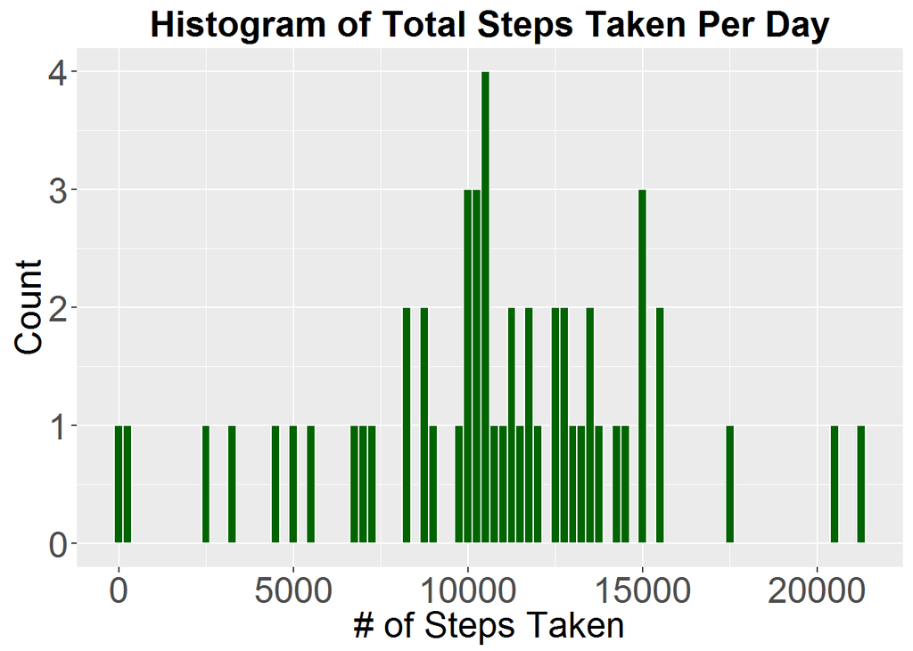

```r
library(ggplot2)
g <- ggplot(total.steps.per.day, aes(x=steps))
g <- g + geom_histogram(binwidth = 250, fill = 'darkgreen', colour = "white")
g <- g + ggtitle("Histogram of Total Steps Taken Per Day")
g <- g + theme(plot.title = element_text (size=20, face="bold"))
g <- g + theme(axis.text.x = element_text(size = 20))
g <- g + labs(x = "# of Steps Taken")
g <- g + theme(axis.title.x = element_text(size = 20))
g <- g + theme(axis.title.y = element_text(size = 20))
g <- g + labs(y = "Count")
g <- g + theme(axis.text.y = element_text(size = 20))
g
```

Third, we calculate the mean and median for this dataset.

```r
mean(total.steps.per.day$steps)
```

```
## [1] 10766.19
```

```r
median(total.steps.per.day$steps)
```

```
## [1] 10765
```

## 3. What is the average daily activity pattern?

First, we make a data frame with average steps per interval.

```r
average.steps.per.interval <- aggregate(steps~interval, activity, mean)
```

Second, we plot a time series plot of the 5-minute interval and the average number of steps.

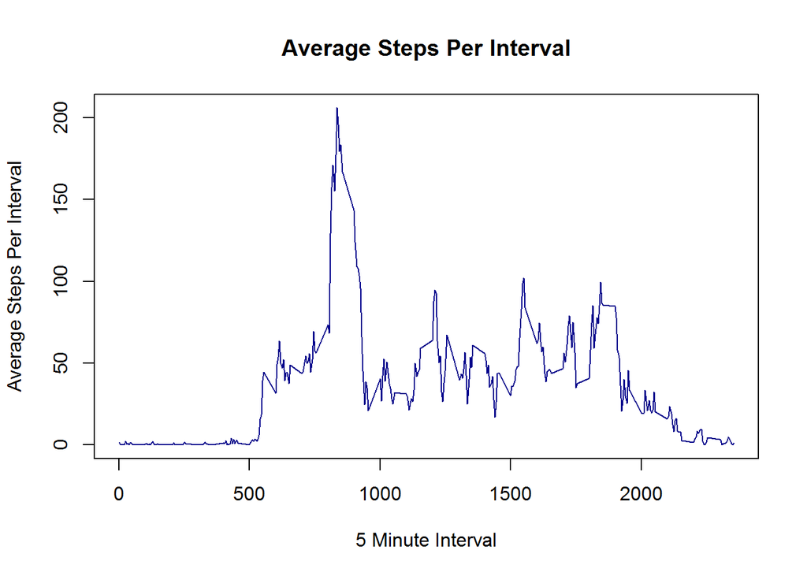

```r
plot(average.steps.per.interval$interval, average.steps.per.interval$steps,
     type="l",
     col = "darkblue",
     xlab = "5 Minute Interval",
     ylab = "Average Steps Per Interval")
title("Average Steps Per Interval")
```

```r
library(dplyr)
summarise_each(average.steps.per.interval, funs(max(., na.rm=TRUE)))
```

```
##   interval    steps
## 1     2355 206.1698
```

## 4. Imputing missing values

There are a number of missing values in the steps column. First, we calculate that number.

```r
missing.steps <- sum(is.na(activity$steps))
missing.steps
```

```
## [1] 2304
```

We find that there are 2304 number of missing values.

Second, we’ll fill these missing values using the mean for that interval using the plyr package.

```r
library(plyr)
impute.mean <- function(x) replace(x, is.na(x), mean(x, na.rm = TRUE))
activity2 <- ddply(activity, ~ interval , transform, steps = impute.mean(steps))
activity2 <- activity2[order(activity2$date), ]
```

We investigate this data set with a histogram for the total number of steps taken each day.

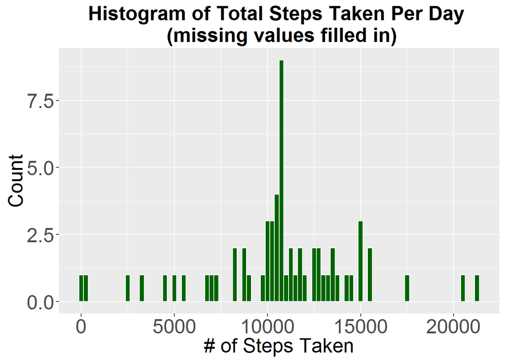

```r
total.steps.per.day2 <- aggregate(steps~date, activity2, sum)
g <- ggplot(total.steps.per.day2, aes(x=steps))
g <- g + geom_histogram(binwidth = 250, fill = 'darkgreen', colour = "white")
g <- g + ggtitle("Histogram of Total Steps Taken Per Day \n (missing values filled in)")
g <- g + theme(plot.title = element_text (size=20, face="bold"))
g <- g + theme(axis.text.x = element_text(size = 20))
g <- g + labs(x = "# of Steps Taken")
g <- g + theme(axis.title.x = element_text(size = 20))
g <- g + theme(axis.title.y = element_text(size = 20))
g <- g + labs(y = "Count")
g <- g + theme(axis.text.y = element_text(size = 20))
g
```

```r
mean.s <- mean(total.steps.per.day$steps)
median.s <- median(total.steps.per.day$steps)
mean.s2 <- mean(total.steps.per.day2$steps)
median.s2 <- median(total.steps.per.day2$steps)
mean.difference <- mean.s - mean.s2
median.difference <- median.s - median.s2
```

## 5. Are there differences in activity patterns between weekdays and weekends?

First, we create a new data set with a new column that indicates whether a day is a weekday or a weekend using the function mutate.

```r
weekend <- c("Saturday", "Sunday")

activity3 <- mutate(activity2,
                    day = factor(1 * (weekdays(activity2$date) %in% weekend),
                    labels = c("weekday", "weekend")))
```

We can now examine average activity for weekend and weekday days, and see that weekday has a spike in activity.

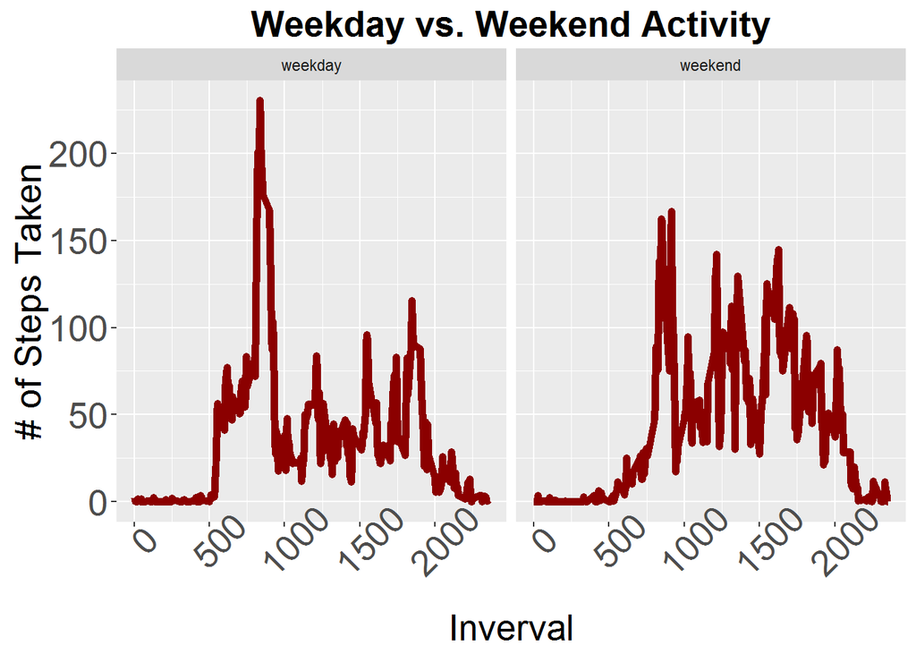

```r
average.steps.per.interval2 <- aggregate(steps~day+interval, activity3, mean)

g <- ggplot(average.steps.per.interval2, aes(x = interval, y = steps)) +
     geom_line(lwd = 2, col = "darkred")
g <- g + ggtitle("Weekday vs. Weekend Activity")
g <- g + theme(plot.title = element_text (size=20, face="bold"))
g <- g + theme(axis.text.x = element_text(size = 20, angle = 45))
g <- g + labs(x = "Inverval")
g <- g + theme(axis.title.x = element_text(size = 20))
g <- g + theme(axis.title.y = element_text(size = 20))
g <- g + labs(y = "# of Steps Taken")
g <- g + theme(axis.text.y = element_text(size = 20))
g <- g + facet_grid(. ~ day)
g
```